# Boqian_Mao_Biostat_620_Lab6

Author

Boqian Mao

```r
library(dplyr)
library(ggplot2)
library(tidytext)
library(readr)

url <- "https://raw.githubusercontent.com/dmcable/BIOSTAT620W26/main/data/mtsamples/mtsamples.csv"
mtsamples <- read_csv(url)
head(mtsamples)
```

```
# A tibble: 6 × 6
   ...1 description         medical_specialty sample_name transcription keywords
  <dbl> <chr>               <chr>             <chr>       <chr>         <chr>
1     0 A 23-year-old whit… Allergy / Immuno… Allergic R… "SUBJECTIVE:… allergy…
2     1 Consult for laparo… Bariatrics        Laparoscop… "PAST MEDICA… bariatr…
3     2 Consult for laparo… Bariatrics        Laparoscop… "HISTORY OF … bariatr…
4     3 2-D M-Mode. Dopple… Cardiovascular /… 2-D Echoca… "2-D M-MODE:… cardiov…
5     4 2-D Echocardiogram  Cardiovascular /… 2-D Echoca… "1.  The lef… cardiov…
6     5 Morbid obesity.  L… Bariatrics        Laparoscop… "PREOPERATIV… bariatr…
```

## Q1

```r
mtsamples %>%
  count(mtsamples$medical_specialty, sort = TRUE) %>%
  nrow()
```

```
[1] 40
```

We have different categories in specialty. These categories are broadly related as medical domains, and many share clinical vocabulary. They are not overlapping as labels, but they do overlap conceptually because some labels represent clinical specialties while others represent note/report types. The distribution is unlikely to be even. It follows a few large categories and many small ones.

## Q2

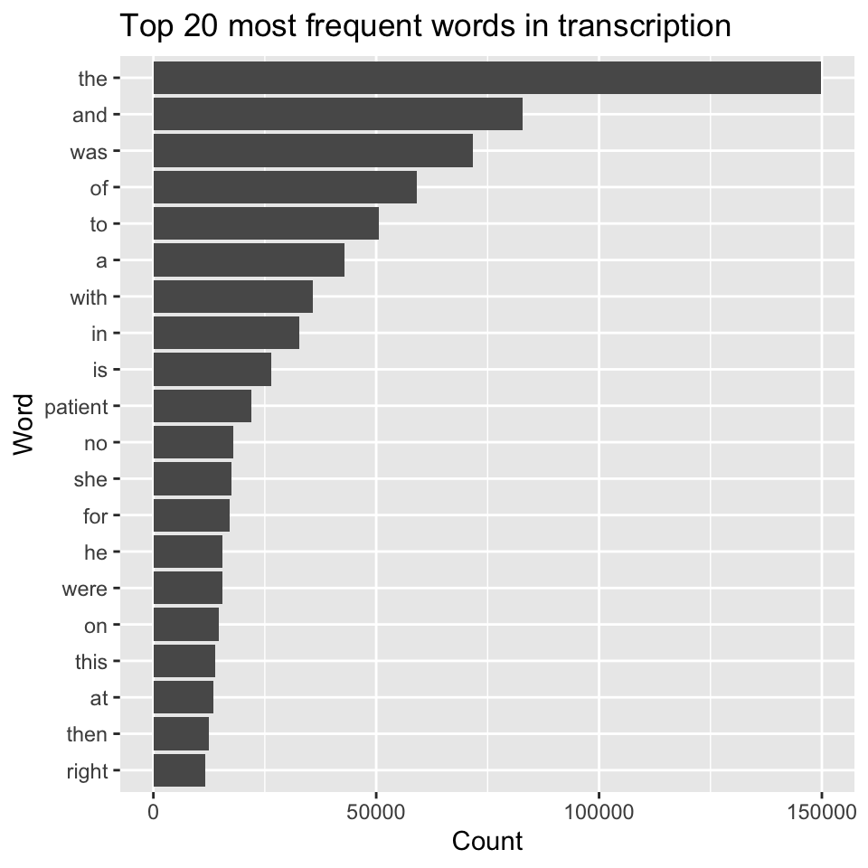

```r
words <- mtsamples %>%
  select(transcription) %>%
  filter(!is.na(transcription)) %>%
  unnest_tokens(word, transcription)

word_counts <- words %>%
  count(word, sort = TRUE)

top20 <- word_counts %>%
  slice_max(n, n = 20)

top20 %>%
  mutate(word = reorder(word, n)) %>%
  ggplot(aes(x = word, y = n)) +
  geom_col() +
  coord_flip() +
  labs(x = "Word", y = "Count", title = "Top 20 most frequent words in transcription")
```

The most frequent tokens are dominated by common English stop words, which is expected. This confirms the tokenization worked. Also, the appearance of words like “patient” is normally consistent with clinical documentation.

## Q3

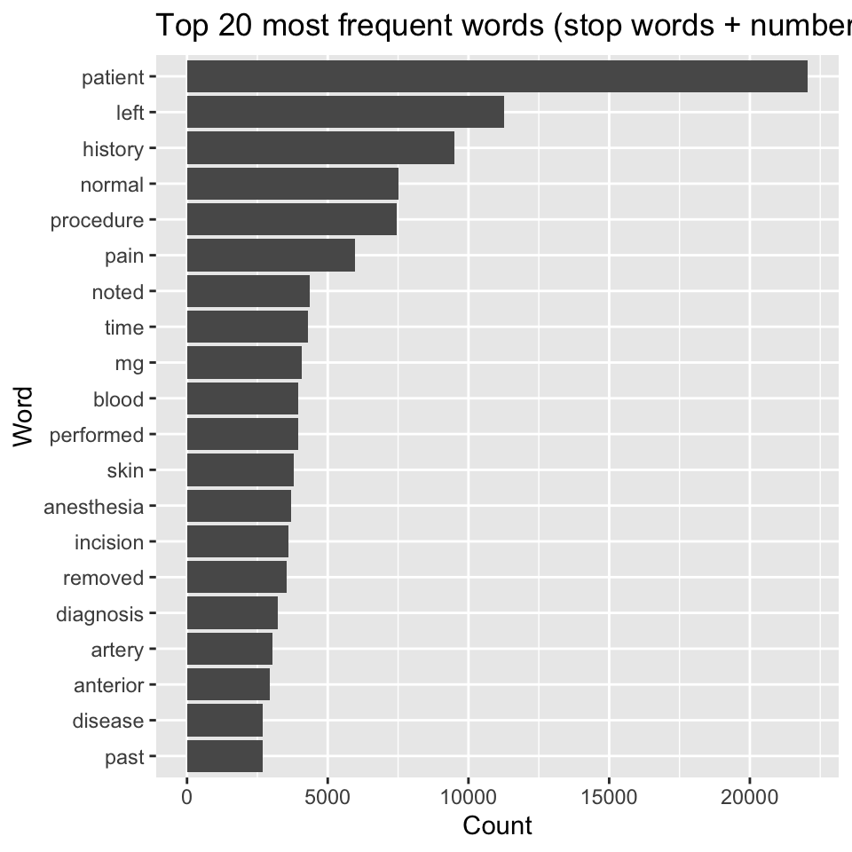

```r
data("stop_words")

words_clean <- words %>%
  anti_join(stop_words, by = "word") %>%
  filter(!grepl("[0-9]", word))

top20_clean <- words_clean %>%
  count(word, sort = TRUE) %>%
  slice_max(n, n = 20)

top20_clean %>%
  mutate(word = reorder(word, n)) %>%
  ggplot(aes(x = word, y = n)) +
  geom_col() +
  coord_flip() +
  labs(x = "Word", y = "Count",
       title = "Top 20 most frequent words (stop words + numbers removed)")
```

After removing stop words and numeric tokens, the most frequent words shift from common function words to clinically meaningful vocabulary. We now see patient related terms, symptom words, and many procedure words.

## Q4

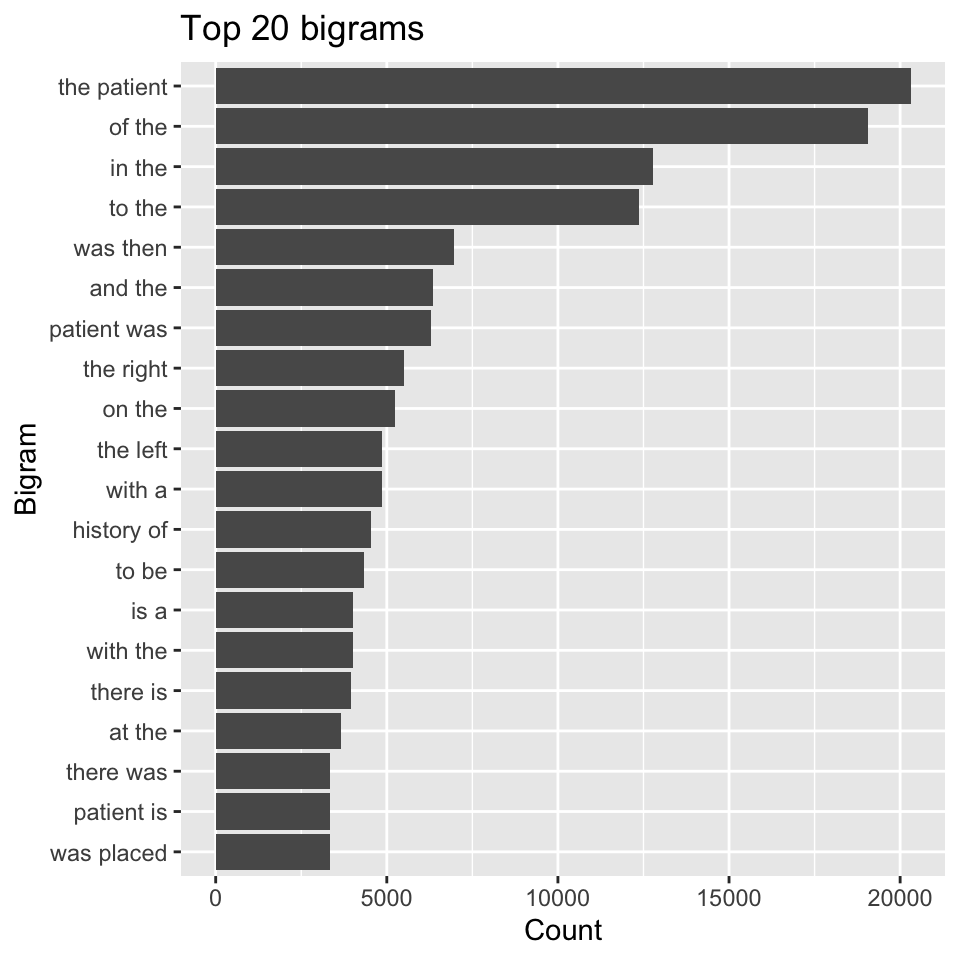

```r
bigrams <- mtsamples %>%
  select(transcription) %>%
  filter(!is.na(transcription)) %>%
  unnest_tokens(bigram, transcription, token = "ngrams", n = 2)

top20_bi <- bigrams %>%
  count(bigram, sort = TRUE) %>%
  slice_max(n, n = 20)

top20_bi %>%
  mutate(bigram = reorder(bigram, n)) %>%
  ggplot(aes(x = bigram, y = n)) +
  geom_col() +
  coord_flip() +
  labs(x = "Bigram", y = "Count", title = "Top 20 bigrams")
```

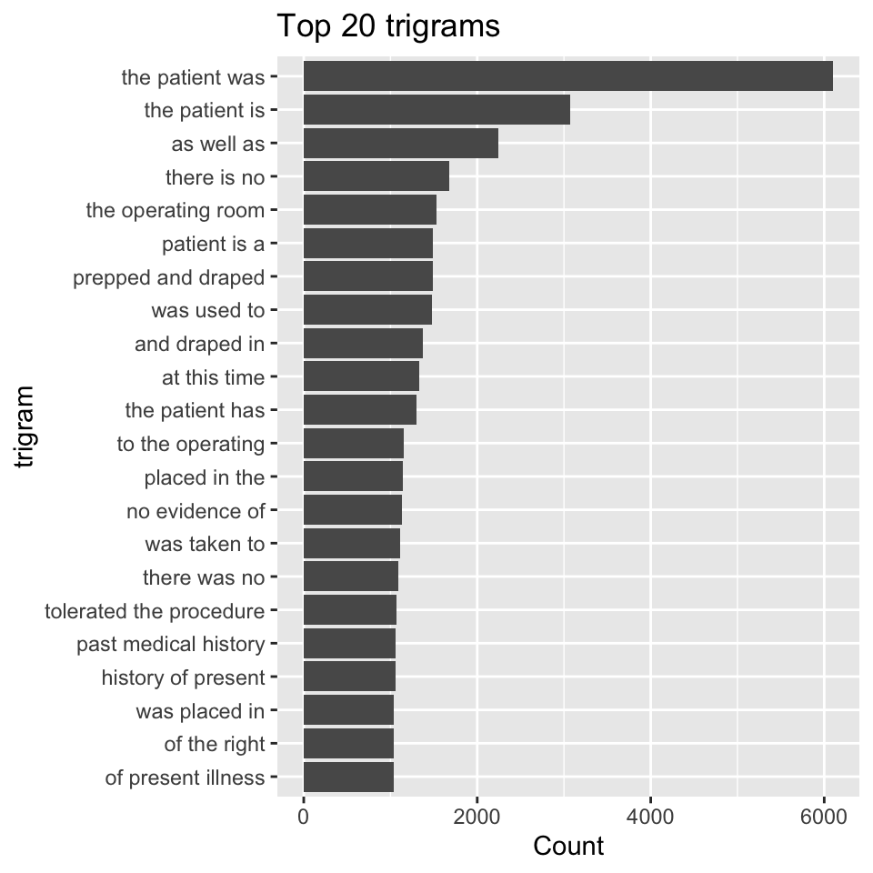

```r
trigrams <- mtsamples %>%
  select(transcription) %>%
  filter(!is.na(transcription)) %>%
  unnest_tokens(trigram, transcription, token = "ngrams", n = 3)

top20_tri <- trigrams %>%
  count(trigram, sort = TRUE) %>%
  slice_max(n, n = 20)

top20_tri %>%
  mutate(trigram = reorder(trigram, n)) %>%
  ggplot(aes(x = trigram, y = n)) +
  geom_col() +
  coord_flip() +
  labs(x = "trigram", y = "Count", title = "Top 20 trigrams")
```

The most frequent bigrams/trigrams are dominated by common narrative templates. Trigrams provide more context than bigrams, but they are still structural rather than topic-specific. This indicates that removing stop words might be more useful for more domain-specific medical concepts.

## Q5

```r
library(tidyr)
target <- "patient"

bigrams <- mtsamples %>%
  filter(!is.na(transcription)) %>%
  unnest_tokens(bigram, transcription, token = "ngrams", n = 2) %>%
  separate(bigram, into = c("word1","word2"), sep = " ")

before <- bigrams %>%
  filter(word2 == target) %>%
  count(word1, sort = TRUE)

after <- bigrams %>%
  filter(word1 == target) %>%
  count(word2, sort = TRUE)

before %>% slice_head(n = 15)
```

```
# A tibble: 15 × 2
   word1         n
   <chr>     <int>
 1 the       20307
 2 this        470
 3 history     101
 4 a            67
 5 and          47
 6 procedure    32
 7 female       26
 8 with         25
 9 use          24
10 old          23
11 sample       23
12 male         22
13 new          19
14 general      16
15 illness      16
```

```r
after  %>% slice_head(n = 15)
```

```
# A tibble: 15 × 2
   word2         n
   <chr>     <int>
 1 was        6293
 2 is         3332
 3 has        1417
 4 tolerated   994
 5 had         888
 6 will        616
 7 denies      552
 8 and         377
 9 states      363
10 does        334
11 also        301
12 in          246
13 did         232
14 to          215
15 the         200
```

## Q6

```r
data("stop_words")

top5_by_spec <- mtsamples %>%
  filter(!is.na(transcription), !is.na(medical_specialty), medical_specialty != "") %>%
  select(medical_specialty, transcription) %>%
  unnest_tokens(word, transcription) %>%
  anti_join(stop_words, by = "word") %>%
  count(medical_specialty, word, sort = TRUE) %>%
  group_by(medical_specialty) %>%
  slice_max(n, n = 5) %>%
  ungroup() %>%
  arrange(medical_specialty, desc(n))

head(top5_by_spec, 20)
```

```
# A tibble: 20 × 3
   medical_specialty          word          n
   <chr>                      <chr>     <int>
 1 Allergy / Immunology       history      38
 2 Allergy / Immunology       noted        23
 3 Allergy / Immunology       patient      22
 4 Allergy / Immunology       allergies    21
 5 Allergy / Immunology       nasal        13
 6 Allergy / Immunology       past         13
 7 Autopsy                    left         83
 8 Autopsy                    1            66
 9 Autopsy                    inch         59
10 Autopsy                    neck         55
11 Autopsy                    anterior     47
12 Bariatrics                 patient      62
13 Bariatrics                 history      50
14 Bariatrics                 weight       36
15 Bariatrics                 surgery      34
16 Bariatrics                 gastric      30
17 Cardiovascular / Pulmonary left       1550
18 Cardiovascular / Pulmonary patient    1516
19 Cardiovascular / Pulmonary artery     1085
20 Cardiovascular / Pulmonary 2           759
```

## Q7

```r
data("stop_words")
target <- "diabetes"

word_by_spec <- mtsamples %>%
  filter(!is.na(transcription), !is.na(medical_specialty), medical_specialty != "") %>%
  select(medical_specialty, transcription) %>%
  unnest_tokens(word, transcription) %>%
  anti_join(stop_words, by = "word") %>%
  group_by(medical_specialty) %>%
  summarize(
    total_words = n(),
    target_count = sum(word == target),
    rate = target_count / total_words,
    .groups = "drop"
  ) %>%
  arrange(desc(rate))

word_by_spec %>% slice_head(n = 10)
```

```
# A tibble: 10 × 4
   medical_specialty             total_words target_count    rate
   <chr>                               <int>        <int>   <dbl>
 1 Diets and Nutritions                 1988           14 0.00704
 2 Bariatrics                           3781           11 0.00291
 3 General Medicine                    68145          124 0.00182
 4 Endocrinology                        6469           11 0.00170
 5 Letters                              5365            9 0.00168
 6 Consult - History and Phy.         158615          255 0.00161
 7 SOAP / Chart / Progress Notes       30657           48 0.00157
 8 Discharge Summary                   25147           33 0.00131
 9 Psychiatry / Psychology             20361           26 0.00128
10 Nephrology                          19008           20 0.00105
```

I checked whether the word diabetes is used more in some specialties than others. After removing stop words, I computed the proportion of tokens equal to diabetes within each specialty.